# Making plots with `ggplot2`: Barplots and Scatterplots

# Inside `aes()` or outside `aes()`?

What is the difference between these two graphs?

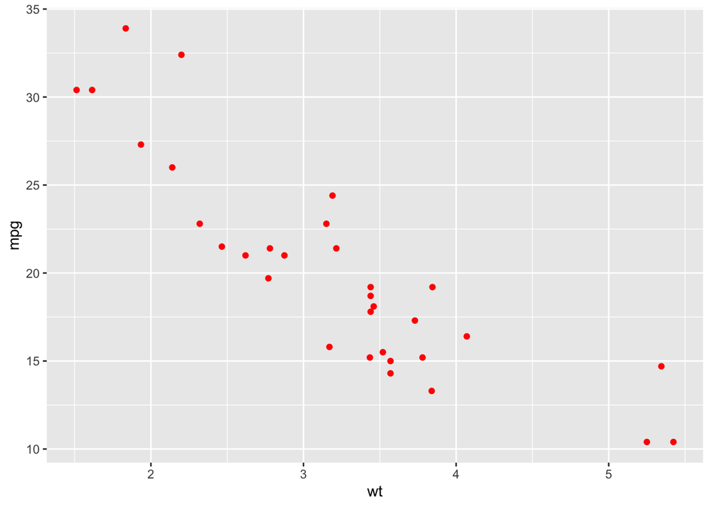

```r
# set color outside aesthetics
ggplot(mtcars, aes(x=wt, y=mpg)) +
  geom_point(color="red")
```

```r
# set color in aesthetics
ggplot(mtcars, aes(x=wt, y=mpg)) +
  geom_point(aes(color=am))
```

[output not shown]

Now let’s change the shape of the points to designate the different groups.

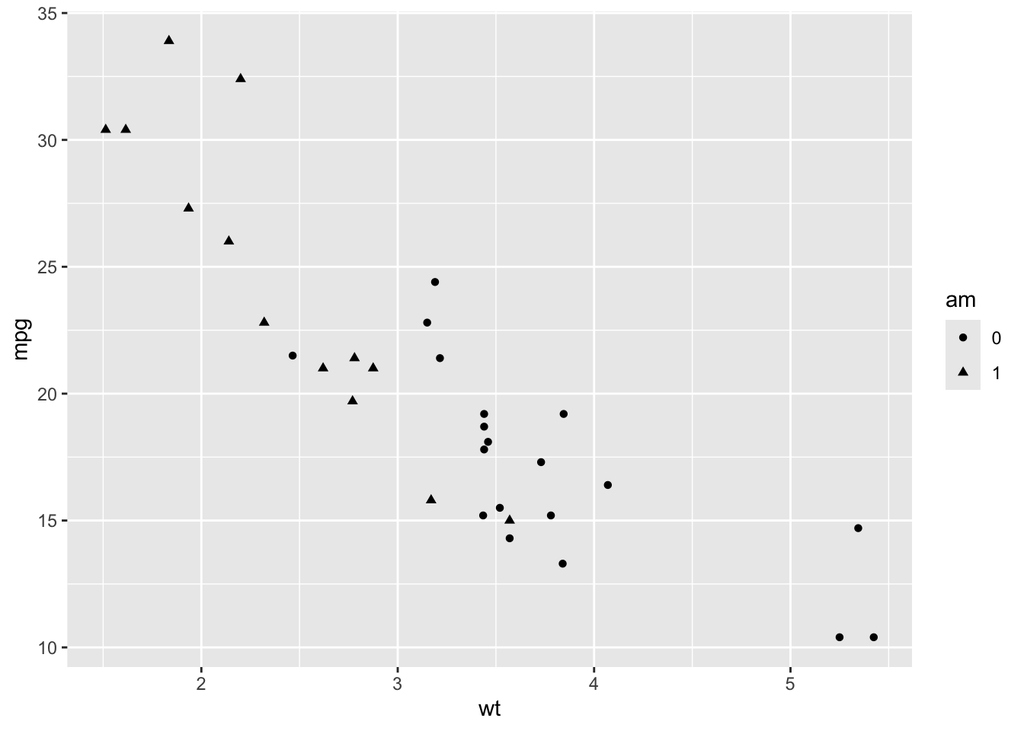

```r
#color in aesthetics and then customize with scale_color_manual()
ggplot(mtcars, aes(x=wt, y=mpg)) +
  geom_point(aes(shape=am))
```

We can add back in color:

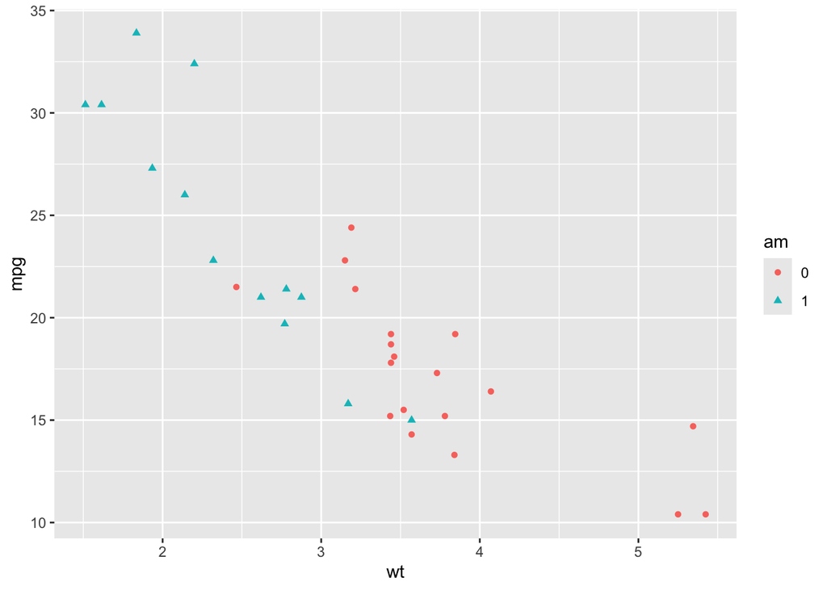

```r
#color in aesthetics and then customize with scale_color_manual()
ggplot(mtcars, aes(x=wt, y=mpg)) +
  geom_point(aes(shape=am, color=am))
```

And we can add a size argument as well:

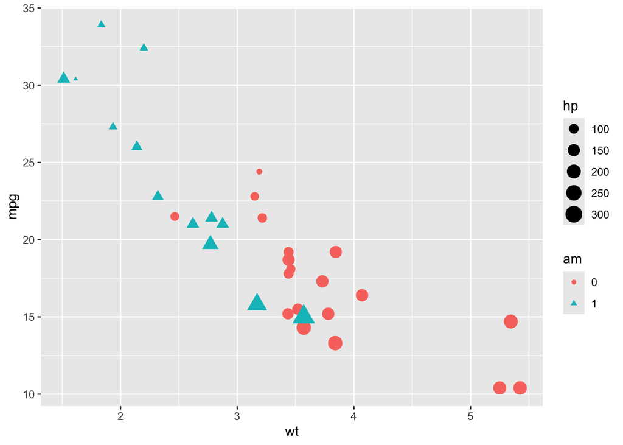

```r
#color in aesthetics and then customize with scale_color_manual()
ggplot(mtcars, aes(x=wt, y=mpg)) +
  geom_point(aes(shape=am, color=am, size=hp))
```

**Tip**

- If the thing you are trying to change (color, shape, size, etc.) depends on a variable, you should put in *inside* the aesthetics
- If the thing you are trying to change (color, shape, size, etc.) should happen for all things, you should not put it inside the aesthetics.

# Customizing Colors in Aesthetics

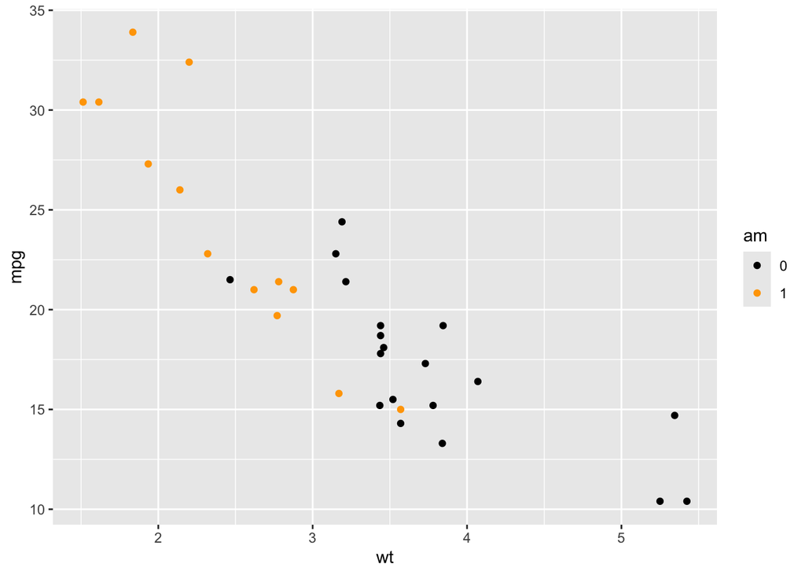

```r
#color in aesthetics and then customize with scale_color_manual()
ggplot(mtcars, aes(x=wt, y=mpg)) +
  geom_point(aes(color=am)) +
  scale_color_manual(values=c("black", "orange"))
```

# Global vs. Local Aesthetics

Global aesthetic mappings apply to all geometries and can be defined when you initially call `ggplot()`. All the geometries added as layers will default to this mapping. Local aesthetic mappings add additional information or override the default mappings.

```r
#set color = am as a global aesthetic in ggplot()
ggplot(mtcars, aes(x=wt, y=mpg, color=am)) +
  geom_point()
```

[output not shown]

```r
#set color = am as a local aesthetic in geom_point
ggplot(mtcars, aes(x=wt, y=mpg)) +
  geom_point(aes(color=am))
```

[output not shown]

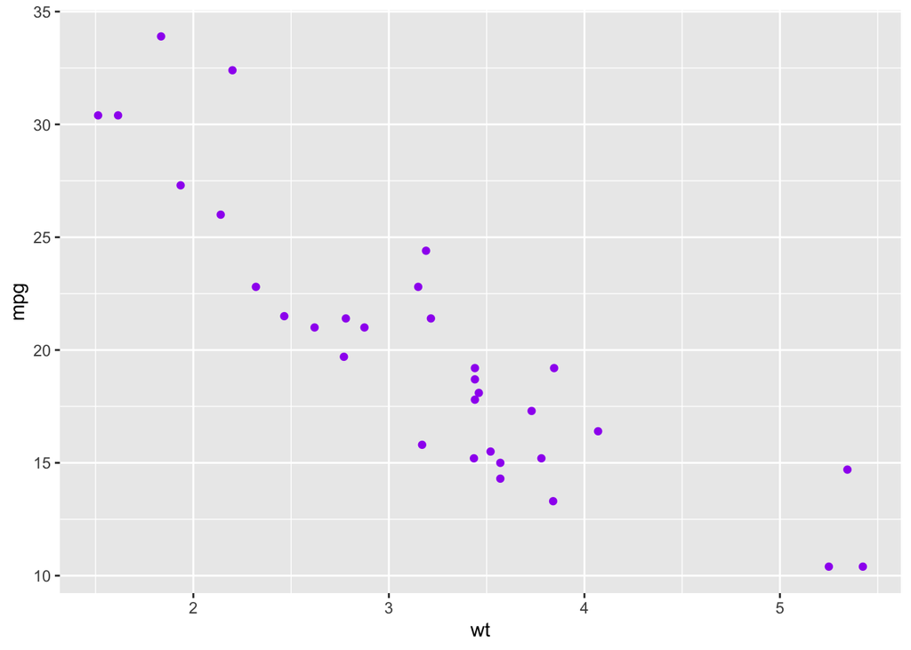

```r
# set color = am as global aesthetic in ggplot()
# then overwrite color = am with a local aesthetic in geom_point
# do it first with empty geom_point, then define color
ggplot(mtcars, aes(x=wt, y=mpg, color=am)) +
  geom_point(color="purple")
```

# Piping in Data

You can define your dataset within ggplot as we have been doing or you can pipe in a wrangled version of your data.

Here is our basic figure, with our dataset defined within `ggplot()`:

```r
ggplot(mtcars, aes(x=wt, y=mpg)) +
  geom_point(aes(color=am))
```

[output not shown]

If we pipe in the same data set, we get the same plot:

```r
mtcars |>
  ggplot(aes(x=wt, y=mpg)) +
  geom_point(aes(color=am))
```

[output not shown]

But piping in the data allows us to use our wrangling skills to send in a slightly (or sometimes very) different dataset without having to create a new object. Here is the same plot, but with am filtered for only the 0 values:

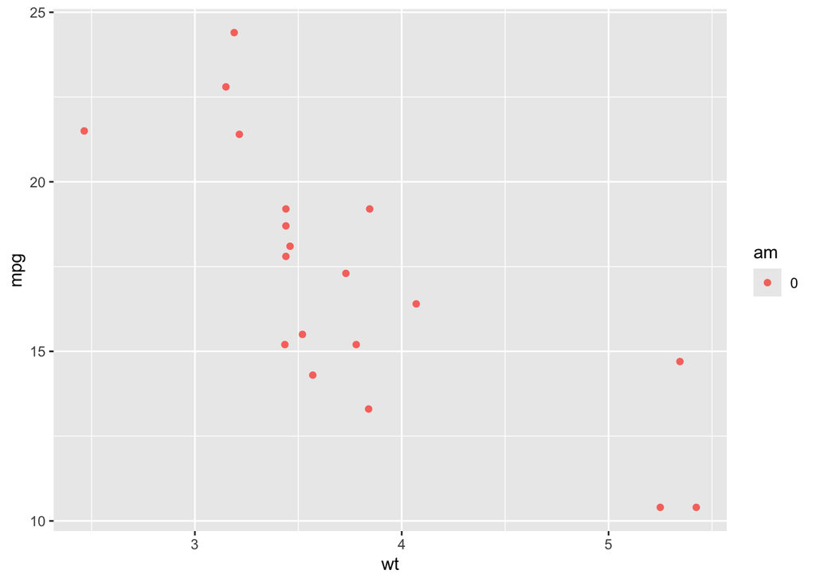

```r
mtcars |>
  filter(am==0) |>
  ggplot(aes(x=wt, y=mpg)) +
  geom_point(aes(color=am))
```

# Quick Introduction to Themes

There are these things in `ggplot()` called themes that change the look of a figure. Here are a few examples:

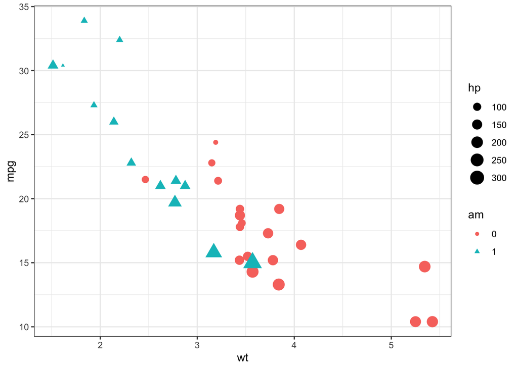

```r
#color in aesthetics and then customize with scale_color_manual()
ggplot(mtcars, aes(x=wt, y=mpg)) +
  geom_point(aes(shape=am, color=am, size=hp)) +
  theme_bw()
```

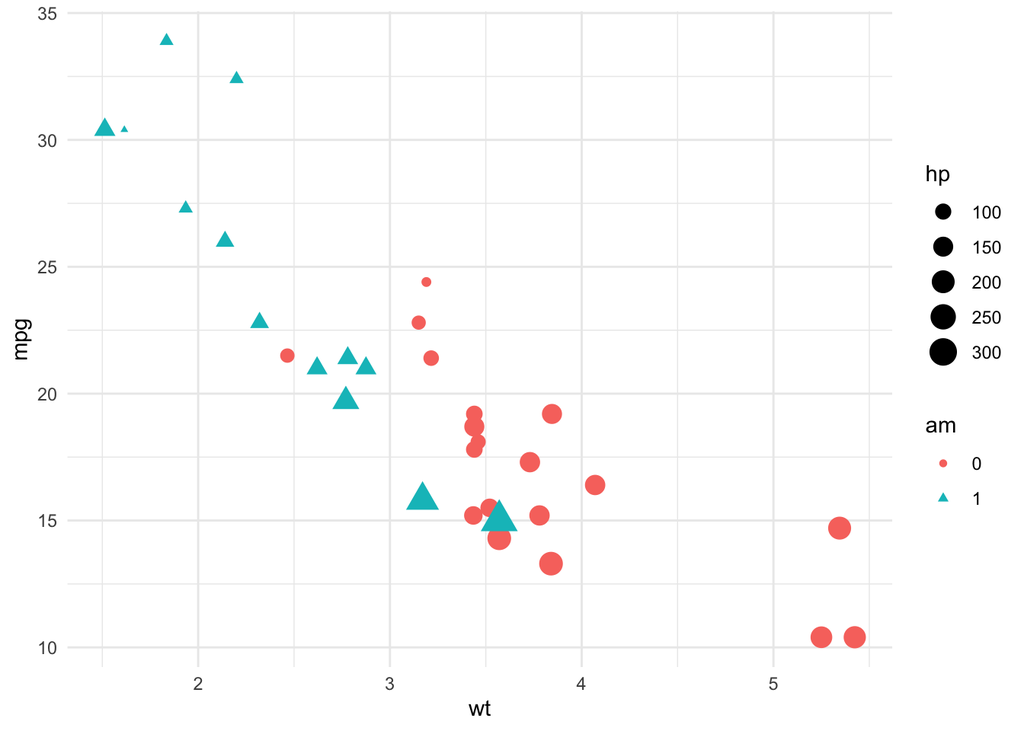

```r
ggplot(mtcars, aes(x=wt, y=mpg)) +
  geom_point(aes(shape=am, color=am, size=hp)) +
  theme_minimal()
```

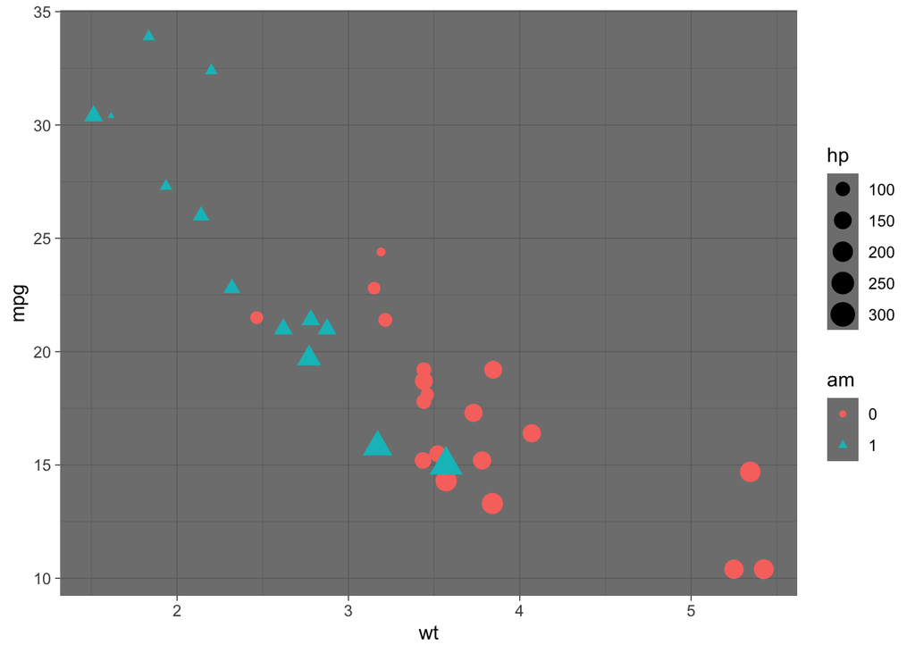

```r
ggplot(mtcars, aes(x=wt, y=mpg)) +
  geom_point(aes(shape=am, color=am, size=hp)) +
  theme_dark()
```